# MovieLens Project Question Notebook

### `Project - MovieLens Data Analysis`

The GroupLens Research Project is a research group in the Department of Computer Science and Engineering at the University of Minnesota. The data is widely used for collaborative filtering and other filtering solutions. However, we will be using this data to act as a means to demonstrate our skill in using Python to “play” with data.

### `Objective:`

- To implement the techniques learnt as a part of the course.

### `Datasets Information:`

*rating.csv:* It contains information on ratings given by the users to a particular movie.

- user id: id assigned to every user
- movie id: id assigned to every movie
- rating: rating given by the user
- timestamp: Time recorded when the user gave a rating

*movie.csv:* File contains information related to the movies and their genre.

- movie id: id assigned to every movie
- movie title: Title of the movie
- release date: Date of release of the movie
- Action: Genre containing binary values (1 - for action 0 - not action)
- Adventure: Genre containing binary values (1 - for adventure 0 - not adventure)
- Animation: Genre containing binary values (1 - for animation 0 - not animation)
- Children’s: Genre containing binary values (1 - for children's 0 - not children's)
- Comedy: Genre containing binary values (1 - for comedy 0 - not comedy)
- Crime: Genre containing binary values (1 - for crime 0 - not crime)
- Documentary: Genre containing binary values (1 - for documentary 0 - not documentary)
- Drama: Genre containing binary values (1 - for drama 0 - not drama)
- Fantasy: Genre containing binary values (1 - for fantasy 0 - not fantasy)
- Film-Noir: Genre containing binary values (1 - for film-noir 0 - not film-noir)
- Horror: Genre containing binary values (1 - for horror 0 - not horror)
- Musical: Genre containing binary values (1 - for musical 0 - not musical)
- Mystery: Genre containing binary values (1 - for mystery 0 - not mystery)
- Romance: Genre containing binary values (1 - for romance 0 - not romance)
- Sci-Fi: Genre containing binary values (1 - for sci-fi 0 - not sci-fi)
- Thriller: Genre containing binary values (1 - for thriller 0 - not thriller)
- War: Genre containing binary values (1 - for war 0 - not war)
- Western: Genre containing binary values (1 - for western - not western)

*user.csv:* It contains information of the users who have rated the movies.

- user id: id assigned to every user
- age: Age of the user
- gender: Gender of the user
- occupation: Occupation of the user
- zip code: Zip code of the use

**`Please provide your insights wherever necessary.`**

### `Learning Outcomes:`

- Exploratory Data Analysis
- Visualization using Python
- Pandas – groupby, merging

### `Domain`

- Internet and Entertainment

**Note that the project will need you to apply the concepts of groupby and merging extensively.**

### 1. Import the necessary packages - 2.5 marks

```python
#import numpy,pandas,matplotlib and seaborn using import statement
import pandas as pd
import numpy as np
from matplotlib import pyplot as plt
from matplotlib.dates import DateFormatter
import seaborn as sns
import datetime

%matplotlib inline
#set color for seaborn to have a appearing plots
sns.set(color_codes=True)
```

### 2. Read the 3 datasets into dataframes - 2.5 marks

```python
#Read files using pd.read_csv function
rating = pd.read_csv("data.csv")
movie = pd.read_csv("item.csv")
user = pd.read_csv("user.csv")
```

### 3. Apply info, shape, describe, and find the number of missing values in the data. Present at least 3 observations from these operations - 2.5 marks

- Note that you will need to do it for all the three datasets seperately

```python
#helps to find dataframe column type
print(rating.info())
print('')
#five point summary
print(rating.describe())
print('')
#number of rows and columns
print(rating.shape)
print('')
#isnull.sum() provides column wise null value count and
print(rating.isnull().sum())
```

```
<class 'pandas.core.frame.DataFrame'>
RangeIndex: 100000 entries, 0 to 99999
Data columns (total 4 columns):
 #   Column     Non-Null Count   Dtype
---  ------     --------------   -----
 0   user id    100000 non-null  int64
 1   movie id   100000 non-null  int64
 2   rating     100000 non-null  int64
 3   timestamp  100000 non-null  int64
dtypes: int64(4)
memory usage: 3.1 MB
None

            user id       movie id         rating     timestamp
count  100000.00000  100000.000000  100000.000000  1.000000e+05
mean      462.48475     425.530130       3.529860  8.835289e+08
std       266.61442     330.798356       1.125674  5.343856e+06
min         1.00000       1.000000       1.000000  8.747247e+08
25%       254.00000     175.000000       3.000000  8.794487e+08
50%       447.00000     322.000000       4.000000  8.828269e+08
75%       682.00000     631.000000       4.000000  8.882600e+08
max       943.00000    1682.000000       5.000000  8.932866e+08

(100000, 4)

user id      0
movie id     0
rating       0
timestamp    0
dtype: int64
```

```python
#helps to find dataframe column type
print(movie.info())
print('')
#five point summary
print(movie.describe())
print('')
#number of rows and columns
print(movie.shape)
print('')
#isnull.sum() provides column wise null value count and
print(movie.isnull().sum())
```

```
<class 'pandas.core.frame.DataFrame'>
RangeIndex: 1681 entries, 0 to 1680
Data columns (total 22 columns):
 #   Column        Non-Null Count  Dtype
---  ------        --------------  -----
 0   movie id      1681 non-null   int64
 1   movie title   1681 non-null   object
 2   release date  1681 non-null   object
 3   unknown       1681 non-null   int64
 4   Action        1681 non-null   int64
 5   Adventure     1681 non-null   int64
 6   Animation     1681 non-null   int64
 7   Childrens     1681 non-null   int64
 8   Comedy        1681 non-null   int64
 9   Crime         1681 non-null   int64
 10  Documentary   1681 non-null   int64
 11  Drama         1681 non-null   int64
 12  Fantasy       1681 non-null   int64
 13  Film-Noir     1681 non-null   int64
 14  Horror        1681 non-null   int64
 15  Musical       1681 non-null   int64
 16  Mystery       1681 non-null   int64
 17  Romance       1681 non-null   int64
 18  Sci-Fi        1681 non-null   int64
 19  Thriller      1681 non-null   int64
 20  War           1681 non-null   int64
 21  Western       1681 non-null   int64
dtypes: int64(20), object(2)
memory usage: 289.0+ KB
None

          movie id      unknown       Action    Adventure    Animation  \
count  1681.000000  1681.000000  1681.000000  1681.000000  1681.000000
mean    841.841761     0.000595     0.149316     0.080309     0.024985
std     485.638077     0.024390     0.356506     0.271852     0.156126
min       1.000000     0.000000     0.000000     0.000000     0.000000
25%     422.000000     0.000000     0.000000     0.000000     0.000000
50%     842.000000     0.000000     0.000000     0.000000     0.000000
75%    1262.000000     0.000000     0.000000     0.000000     0.000000
max    1682.000000     1.000000     1.000000     1.000000     1.000000
```

[output cut: 41 more lines]

```
Comedy          0
Crime           0
Documentary     0
Drama           0
Fantasy         0
Film-Noir       0
Horror          0
Musical         0
Mystery         0
Romance         0
Sci-Fi          0
Thriller        0
War             0
Western         0
dtype: int64
```

```python
#helps to find dataframe column type
print(user.info())
print('')
#five point summary
print(user.describe())
print('')
#number of rows and columns
print(user.shape)
print('')
#isnull.sum() provides column wise null value count and
print(user.isnull().sum())
```

```
<class 'pandas.core.frame.DataFrame'>
RangeIndex: 943 entries, 0 to 942
Data columns (total 5 columns):
 #   Column      Non-Null Count  Dtype
---  ------      --------------  -----
 0   user id     943 non-null    int64
 1   age         943 non-null    int64
 2   gender      943 non-null    object
 3   occupation  943 non-null    object
 4   zip code    943 non-null    object
dtypes: int64(2), object(3)
memory usage: 37.0+ KB
None

          user id         age
count  943.000000  943.000000
mean   472.000000   34.051962
std    272.364951   12.192740
min      1.000000    7.000000
25%    236.500000   25.000000
50%    472.000000   31.000000
75%    707.500000   43.000000
max    943.000000   73.000000

(943, 5)

user id       0
age           0
gender        0
occupation    0
zip code      0
dtype: int64
```

```python
#Extra code
print(user[user['gender']=='F'].count())
print('')
print(user.isnull().sum().sum())
print('')
print(movie.head())
print('')
print(max(rating['user id']))
print('')
print(rating.head())
print('')
#Get relevant percentiles and see their distribution.
rating['rating'].quantile([0, 0.1, 0.2, 0.3, 0.4, 0.5, 0.6, 0.7,0.75, 0.8, 0.9, 1])
print(3-(4-3)*1.5)
print('')
print(4+(4-3)*1.5)
print(np.sum(movie['Action'] !=0))
movie.count(axis=0)
```

[output not shown]

### 4. Find the number of movies per genre using the item data - 2.5 marks

```python
#Sum is a groupby function used to get the sum of movies per genre
movie.loc[:,'unknown':'Western'].sum()
```

```
unknown          1
Action         251
Adventure      135
Animation       42
Childrens      122
Comedy         505
Crime          109
Documentary     50
Drama          725
Fantasy         22
Film-Noir       24
Horror          92
Musical         56
Mystery         61
Romance        247
Sci-Fi         101
Thriller       251
War             71
Western         27
dtype: int64
```

**Insights:**

- 1681 movies are classified into 19 genre
- There is one movie under unknown genre
- Lowest count genre is Fantasy and highest is Drama

### 5. Drop the movie where the genre is unknown - 2.5 marks

```python
len(movie)
```

```
1681
```

```python
#filter is used to select genres except unknown
movie = movie[movie['unknown']!=1]
```

```python
#display dataset after dropping a column
len(movie)
```

```
1680
```

```python
movie.drop('unknown',axis=1,inplace=True)
```

**Insights:**

- The unknown genre is filtered from the dataset
- There was one movie under the unknown genre

### 6. Find the movies that have more than one genre - 5 marks

hint: use sum on the axis = 1

Display movie name, number of genres for the movie in dataframe

and also print(total number of movies which have more than one genres)

```python
#get the sum of genres by column using index location
number_of_genres = movie.iloc[:, 3:].sum(axis=1)
#check for genre greater than 1
sub =movie[number_of_genres > 1]
#caculate number of genres each movie falls under and creating a new column
sub['total_movies']=sub.iloc[:, 3:].sum(axis=1)
#print the movie title and number of genres
print(sub.iloc [:, [1,21]])
print('')
#print total number of movies with more than one genre
print(f'Total Number of movies with more than one genre: {len(sub)}')
```

```
             movie title  total_movies
0             Toy Story              3
1             GoldenEye              3
3            Get Shorty              3
4               Copycat              3
6        Twelve Monkeys              2
...                  ...           ...
1667  MURDER and murder              3
1668            Tainted              2
1671             Mirage              2
1677          B. Monkey              2
1678      Sliding Doors              2

[849 rows x 2 columns]

Total Number of movies with more than one genre: 849
```

**Insights:**

- There are totally 849 movies out of 1681 for which the genre is more than 1

### 7. Univariate plots of columns: 'rating', 'Age', 'release year', 'Gender' and 'Occupation' - 10 marks

*HINT: Use distplot for age and countplot for release year, ratings,*

*HINT: Please refer to the below snippet to understand how to get to release year from release date. You can use str.split() as depicted below or you could convert it to pandas datetime format and extract year (.dt.year)*

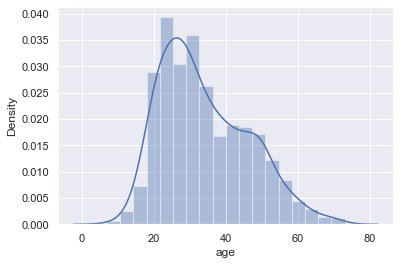

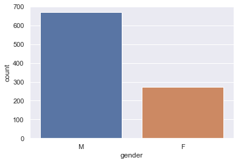

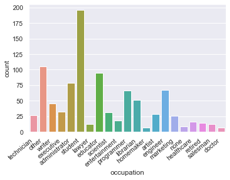

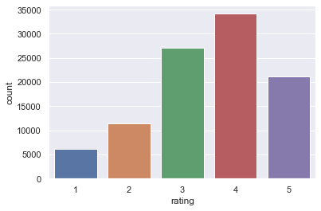

```python
#Distplot with KDE to plot the age
sns.distplot(user['age'])
plt.show()
# countplot to plot gender,occupation and rating
sns.countplot(x='gender', data=user)
plt.show()
ax = sns.countplot(x="occupation", data=user)
ax.set_xticklabels(ax.get_xticklabels(), rotation=40, ha="right")
#plt.tight_layout()
plt.show()
sns.countplot(x='rating', data=rating);
plt.show()
```

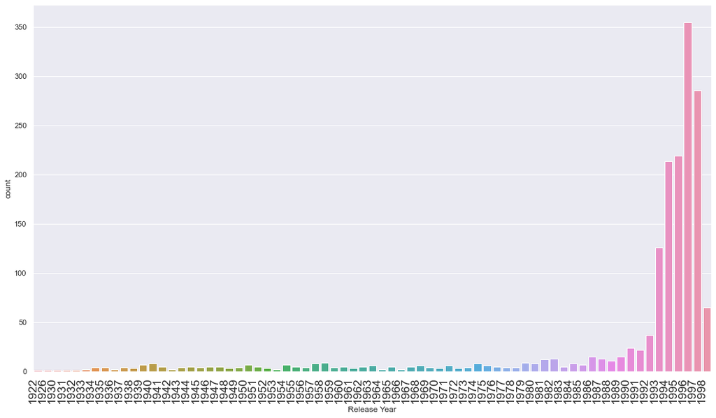

```python
#Pandas DateTimeIndex to convert the release date and take year from date
#create a new column with release year
movie['Release Year']=pd.to_datetime(movie['release date']).dt.year
#Plot year using count plot and find number of release per year
ax = sns.countplot(x='Release Year', data=movie)
#set the figure size
plt.rcParams["figure.figsize"] = (20, 10)
#set the font and alignment of the x label
plt.xticks(
    rotation=90,
    horizontalalignment='right',
    fontweight='light',
    fontsize='x-large'
)
plt.show()
```

**Insights:**

- Age distplot: Age 20 to 40 has more density distribution
- Gender Plot: Male users provided more rating than female users
- Occupation plot: student provided the highest number of movie ratings where as doctors and home makers provided the lowest number of movie ratings
- Rating plot: rating 1 has the lowest count and 4 has the highest count
- Release year plot: release year of movie from 1993 is higher and it drops in 1998

### 8. Visualize how popularity of genres has changed over the years - 10 marks

Note that you need to use the **percent of number of releases in a year** as a parameter of popularity of a genre

Hint 1: You need to reach to a data frame where the release year is the index and the genre is the column names (one cell shows the number of release in a year in one genre) or vice versa. (Drop unnecessary column if there are any)

Hint 2: Find the total number of movies release in a year(use item dataset to get count of movies released in a particular year, store that value in a new column as 'total'). Now divide the value of each genre in that year by total to get percentage number of release in a particular year. `(df.div(df['total'], axis= 0) * 100)`

Once that is achieved, you can either use univariate plots or can use the heatmap to visualise all the changes over the years in one go.

Hint 3: Use groupby on the relevant column and use sum() on the same to find out the number of releases in a year/genre.

```python
#create a copy of movie dataset
df= pd.DataFrame(movie).copy()
#Group df by release year
df_releaseyr = df.groupby('Release Year').sum()
#drop unnecessary columns
df_releaseyr.drop(['movie id'], axis=1,inplace=True)
```

```python
# Find total number of movies released in a year
dt_total = movie.groupby('Release Year')['movie id'].count().reset_index().rename(columns={'movie id':'Total'}).set_index('Release Year')
```

```python
# join total number of movie released with df_releaseyr dataframe
df_releaseyr = df_releaseyr.join(dt_total)
print(df_releaseyr)
```

```
              Action  Adventure  Animation  Childrens  Comedy  Crime  \
Release Year
1922               0          0          0          0       0      0
1926               0          0          0          0       0      0
1930               0          0          0          0       0      0
1931               0          0          0          0       0      1
1932               0          0          0          0       0      0
...              ...        ...        ...        ...     ...    ...
1994              30         13          4         15      82      8
1995              40         22          6         21      63     11
1996              44         24          9         21     108     21
1997              46         20          3         22      87     30
1998              12          3          0          1      13      7

              Documentary  Drama  Fantasy  Film-Noir  Horror  Musical  \
```

[output cut: 28 more lines]

```python
#use division to divide each value in a dataset by total movies and take percentage
df2=(df_releaseyr.div(df_releaseyr['Total'], axis= 0) * 100).drop('Total',axis=1).T
df2
```

| Release Year | 1922 | 1926 | 1930 | 1931 | 1932 | 1933 | 1934 | 1935 | 1936 | 1937 | ... | 1989 | 1990 | 1991 | 1992 | 1993 | 1994 | 1995 | 1996 | 1997 | 1998 |
| --- | --- | --- | --- | --- | --- | --- | --- | --- | --- | --- | --- | --- | --- | --- | --- | --- | --- | --- | --- | --- | --- |
| Action | 0.0 | 0.0 | 0.0 | 0.0 | 0.0 | 0.0 | 0.0 | 0.0 | 0.0 | 0.0 | ... | 40.000000 | 29.166667 | 9.090909 | 21.621622 | 15.873016 | 14.018692 | 18.264840 | 12.394366 | 16.083916 | 18.461538 |
| Adventure | 0.0 | 0.0 | 0.0 | 0.0 | 0.0 | 0.0 | 0.0 | 0.0 | 0.0 | 0.0 | ... | 26.666667 | 4.166667 | 4.545455 | 2.702703 | 7.142857 | 6.074766 | 10.045662 | 6.760563 | 6.993007 | 4.615385 |
| Animation | 0.0 | 0.0 | 0.0 | 0.0 | 0.0 | 0.0 | 0.0 | 0.0 | 0.0 | 25.0 | ... | 0.000000 | 0.000000 | 4.545455 | 5.405405 | 0.793651 | 1.869159 | 2.739726 | 2.535211 | 1.048951 | 0.000000 |
| Childrens | 0.0 | 0.0 | 0.0 | 0.0 | 0.0 | 0.0 | 0.0 | 0.0 | 0.0 | 25.0 | ... | 0.000000 | 4.166667 | 4.545455 | 2.702703 | 4.761905 | 7.009346 | 9.589041 | 5.915493 | 7.692308 | 1.538462 |
| Comedy | 0.0 | 0.0 | 0.0 | 0.0 | 0.0 | 50.0 | 50.0 | 50.0 | 50.0 | 50.0 | ... | 20.000000 | 25.000000 | 27.272727 | 32.432432 | 30.952381 | 38.317757 | 28.767123 | 30.422535 | 30.419580 | 20.000000 |
| Crime | 0.0 | 0.0 | 0.0 | 100.0 | 0.0 | 0.0 | 0.0 | 0.0 | 0.0 | 0.0 | ... | 6.666667 | 12.500000 | 0.000000 | 13.513514 | 5.555556 | 3.738318 | 5.022831 | 5.915493 | 10.489510 | 10.769231 |
| Documentary | 0.0 | 0.0 | 0.0 | 0.0 | 0.0 | 0.0 | 0.0 | 0.0 | 0.0 | 0.0 | ... | 0.000000 | 8.333333 | 4.545455 | 0.000000 | 3.174603 | 4.205607 | 2.283105 | 5.070423 | 2.097902 | 4.615385 |
| Drama | 0.0 | 100.0 | 100.0 | 0.0 | 0.0 | 0.0 | 25.0 | 0.0 | 50.0 | 25.0 | ... | 53.333333 | 50.000000 | 50.000000 | 37.837838 | 50.793651 | 45.327103 | 40.639269 | 47.887324 | 39.510490 | 50.769231 |
| Fantasy | 0.0 | 0.0 | 0.0 | 0.0 | 0.0 | 0.0 | 0.0 | 0.0 | 0.0 | 0.0 | ... | 0.000000 | 0.000000 | 4.545455 | 0.000000 | 0.000000 | 1.401869 | 1.369863 | 1.690141 | 1.398601 | 1.538462 |
| Film-Noir | 0.0 | 0.0 | 0.0 | 100.0 | 0.0 | 0.0 | 0.0 | 0.0 | 0.0 | 0.0 | ... | 0.000000 | 4.166667 | 0.000000 | 0.000000 | 0.793651 | 0.000000 | 0.456621 | 0.281690 | 0.699301 | 3.076923 |
| Horror | 100.0 | 0.0 | 0.0 | 0.0 | 0.0 | 0.0 | 0.0 | 25.0 | 0.0 | 0.0 | ... | 0.000000 | 4.166667 | 4.545455 | 16.216216 | 3.968254 | 3.738318 | 6.392694 | 3.098592 | 2.797203 | 6.153846 |
| Musical | 0.0 | 0.0 | 0.0 | 0.0 | 0.0 | 0.0 | 25.0 | 25.0 | 0.0 | 75.0 | ... | 0.000000 | 0.000000 | 9.090909 | 2.702703 | 1.587302 | 0.934579 | 1.369863 | 2.535211 | 1.748252 | 1.538462 |
| Mystery | 0.0 | 0.0 | 0.0 | 0.0 | 0.0 | 0.0 | 25.0 | 0.0 | 0.0 | 0.0 | ... | 0.000000 | 0.000000 | 0.000000 | 2.702703 | 4.761905 | 0.934579 | 2.283105 | 1.690141 | 6.293706 | 4.615385 |
| Romance | 0.0 | 0.0 | 0.0 | 0.0 | 100.0 | 50.0 | 25.0 | 25.0 | 0.0 | 50.0 | ... | 6.666667 | 16.666667 | 0.000000 | 18.918919 | 12.698413 | 16.355140 | 16.894977 | 10.704225 | 17.832168 | 16.923077 |
| Sci-Fi | 0.0 | 0.0 | 0.0 | 0.0 | 0.0 | 0.0 | 0.0 | 0.0 | 0.0 | 0.0 | ... | 13.333333 | 0.000000 | 18.181818 | 8.108108 | 6.349206 | 3.271028 | 6.849315 | 4.225352 | 4.545455 | 7.692308 |
| Thriller | 0.0 | 0.0 | 0.0 | 100.0 | 0.0 | 0.0 | 0.0 | 25.0 | 0.0 | 0.0 | ... | 13.333333 | 16.666667 | 13.636364 | 13.513514 | 13.492063 | 11.682243 | 17.808219 | 13.239437 | 18.881119 | 27.692308 |
| War | 0.0 | 0.0 | 0.0 | 0.0 | 100.0 | 50.0 | 0.0 | 0.0 | 0.0 | 0.0 | ... | 13.333333 | 0.000000 | 4.545455 | 5.405405 | 3.174603 | 3.271028 | 2.283105 | 2.535211 | 4.895105 | 0.000000 |
| Western | 0.0 | 0.0 | 0.0 | 0.0 | 0.0 | 0.0 | 0.0 | 0.0 | 0.0 | 0.0 | ... | 0.000000 | 8.333333 | 0.000000 | 2.702703 | 1.587302 | 2.803738 | 0.913242 | 0.563380 | 0.000000 | 0.000000 |

18 rows × 71 columns

```
[]
```

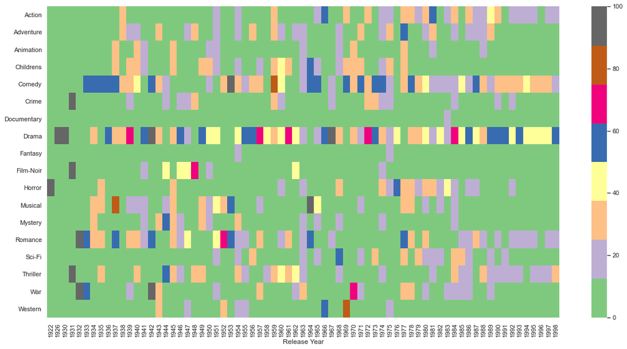

```python
#use heatmap for visualization
ax=sns.heatmap(df2,  cmap='Accent');
#set figure size
plt.rcParams["figure.figsize"] = (25, 15)
#plot the heatmap
plt.plot()
```

### 9. Find the top 25 movies in terms of average ratings for movies that have been rated more than 100 times - 10 marks

Hints :

1. Find the count of ratings and average ratings for every movie.
2. Slice the movies which have ratings more than 100.
3. Sort values according to average rating such that movie which highest rating is on top.
4. Select top 25 movies.
5. You will have to use the .merge() function to get the movie titles.

Note: This question will need you to research about groupby and apply your findings. You can find more on groupby on https://realpython.com/pandas-groupby/.

```python
#count of ratings for every movie
rating.groupby("movie id")["rating"].count()
```

```
movie id
1       452
2       131
3        90
4       209
5        86
       ...
1678      1
1679      1
1680      1
1681      1
1682      1
Name: rating, Length: 1682, dtype: int64
```

```python
#average ratings for every movie
rating.groupby("movie id")["rating"].mean()
```

```
movie id
1       3.878319
2       3.206107
3       3.033333
4       3.550239
5       3.302326
          ...
1678    1.000000
1679    3.000000
1680    2.000000
1681    3.000000
1682    3.000000
Name: rating, Length: 1682, dtype: float64
```

```python
ag_rating = rating.groupby("movie id")["rating"].agg(['mean','count'])
print(ag_rating)
```

```
              mean  count
movie id
1         3.878319    452
2         3.206107    131
3         3.033333     90
4         3.550239    209
5         3.302326     86
...            ...    ...
1678      1.000000      1
1679      3.000000      1
1680      2.000000      1
1681      3.000000      1
1682      3.000000      1

[1682 rows x 2 columns]
```

```python
#check for movie which has rating more than 100
rating.groupby('movie id').filter(lambda x: x['rating'].count() > 100)
```

|  | user id | movie id | rating | timestamp |
| --- | --- | --- | --- | --- |
| 0 | 196 | 242 | 3 | 881250949 |
| 1 | 186 | 302 | 3 | 891717742 |
| 4 | 166 | 346 | 1 | 886397596 |
| 5 | 298 | 474 | 4 | 884182806 |
| 6 | 115 | 265 | 2 | 881171488 |
| ... | ... | ... | ... | ... |
| 99993 | 913 | 209 | 2 | 881367150 |
| 99995 | 880 | 476 | 3 | 880175444 |
| 99996 | 716 | 204 | 5 | 879795543 |
| 99998 | 13 | 225 | 2 | 882399156 |
| 99999 | 12 | 203 | 3 | 879959583 |

64419 rows × 4 columns

```python
#create a dataframe with rating more than 100 for a movie
df_new = rating[rating.groupby('movie id')['rating'].transform('count') > 100]
```

```python
#Merge dataframe with movie to get the title and assign it to new df
df3 = df_new.merge(movie, left_on='movie id', right_on='movie id')
```

```python
#create a group that has average of rating
df_by_mean = df3.groupby(['movie id','movie title'])['rating'].agg(['mean','count'])
```

```python
#display the top 25 movie by average value
print (df_by_mean.sort_values(by='mean',ascending=False).head(25))
```

```
                                                                 mean  count
movie id movie title
408      Close Shave, A                                      4.491071    112
318      Schindler's List                                    4.466443    298
169      Wrong Trousers, The                                 4.466102    118
483      Casablanca                                          4.456790    243
64       Shawshank Redemption, The                           4.445230    283
603      Rear Window                                         4.387560    209
12       Usual Suspects, The                                 4.385768    267
50       Star Wars                                           4.358491    583
178      12 Angry Men                                        4.344000    125
134      Citizen Kane                                        4.292929    198
427      To Kill a Mockingbird                               4.292237    219
357      One Flew Over the Cuckoo's Nest                     4.291667    264
98       Silence of the Lambs, The                           4.289744    390
480      North by Northwest                                  4.284916    179
127      Godfather, The                                      4.283293    413
285      Secrets & Lies                                      4.265432    162
272      Good Will Hunting                                   4.262626    198
657      Manchurian Candidate, The                           4.259542    131
474      Dr. Strangelove or: How I Learned to Stop Worry...  4.252577    194
174      Raiders of the Lost Ark                             4.252381    420
479      Vertigo                                             4.251397    179
313      Titanic                                             4.245714    350
511      Lawrence of Arabia                                  4.231214    173
484      Maltese Falcon, The                                 4.210145    138
172      Empire Strikes Back, The                            4.204360    367
```

### 10. Check for the validity of the below statements with respect to the data provided - 10 marks

- Men watch more drama than women
- Women watch more Sci-Fi than men
- Men watch more Romance than women

**compare the percentages**

**Please pay attention to what should be the denominator while calculating percentages**

1. Merge all the datasets
2. There is no need to conduct statistical tests around this. Just **compare the percentages** and comment on the validity of the above statements.
3. you might want ot use the .sum(), .div() function here.
4. Use number of ratings to validate the numbers. For example, if out of 4000 ratings received by women, 3000 are for drama, we will assume that 75% of the women watch drama.

```python
#Merge all three data set
all_data= user.merge(rating,on='user id').merge(movie,on='movie id')
```

```python
#find nunique to get the total records
print(movie['movie id'].nunique()) #1681
print(rating['movie id'].nunique()) #1682
print(rating['user id'].nunique()) #943
```

```
1680
1682
943
```

```python
#Filter dataframe where gender is female
sub_Female_rating=all_data[all_data["gender"] =='F']
#get the count of rating given by female user
total_female_rating=sub_Female_rating['rating'].count()
```

```python
#Filter dataframe where gender is male
sub_Male_rating=all_data[all_data["gender"] =='M']
#get the count of rating given by male user
total_male_rating=sub_Male_rating['rating'].count()
```

```python
#get the count of rating given by female user for Drama
female_drama_rating=sub_Female_rating.groupby('Drama')['rating'].count()[1]
#get the count of rating given by male user for Drama
male_drama_rating=sub_Male_rating.groupby('Drama')['rating'].count()[1]
#print the number of men watching drama based on the rating given
print(f' % Men watching drama {(male_drama_rating/total_male_rating)*100:.0f}')
#print the number of women watching drama based on the rating given
print(f' % Women watching drama {(female_drama_rating/total_female_rating)*100 :.0f}')
#validate the statement 'Men watch more drama than women'
print(f'Men watch more drama than women : {(female_drama_rating/total_female_rating)*100 < (male_drama_rating/total_male_rating)*100} ')
#.apply(np.ceil)
```

```
 % Men watching drama 39
 % Women watching drama 43
Men watch more drama than women : False
```

```python
#get the count of rating given by female user for Sci-Fi
female_scifi_rating=sub_Female_rating.groupby('Sci-Fi')['rating'].count()[1]
#get the count of rating given by male user for Sci-Fi
male_scifi_rating=sub_Male_rating.groupby('Sci-Fi')['rating'].count()[1]
#print the number of men watching Sci-Fi based on the rating given
print(f' % Men watching scifi {(male_scifi_rating/total_male_rating)*100:.0f}')
#print the number of women watching Sci-Fi based on the rating given
print(f' % Women watching scifi {(female_scifi_rating/total_female_rating)*100:.0f}')
#validate the statement 'Women watch more Sci-Fi than men'
print(f'Women watch more Sci-Fi than men : {(female_scifi_rating/total_female_rating)*100 > (male_scifi_rating/total_male_rating)*100} ')
```

```
 % Men watching scifi 14
 % Women watching scifi 10
Women watch more Sci-Fi than men : False
```

```python
#get the count of rating given by female user for Romance
female_Romance_rating=sub_Female_rating.groupby('Romance')['rating'].count()[1]
#get the count of rating given by male user for Romance
male_Romance_rating=sub_Male_rating.groupby('Romance')['rating'].count()[1]
#print the number of men watching Romance based on the rating given
print(f' % Men watching Romance {(male_Romance_rating/total_male_rating)*100:.0f}')
#print the number of women watching Romance based on the rating given
print(f' % Women watching Romance {(female_Romance_rating/total_female_rating)*100:.0f}')
#validate the statement 'Men watch more Romance than women'
print(f'Men watch more Romance than women : {(female_Romance_rating/total_female_rating)*100 < (male_Romance_rating/total_male_rating)*100} ')
```

```
 % Men watching Romance 18
 % Women watching Romance 23
Men watch more Romance than women : False
```

**Conclusion:**

- % of Men watching drama is 39% and % of Women watching drama is 43% hence Men watch more drama than women is False
- % of Men watching scifi is 14% and % of Women watching scifi is 10% hence Women watch more Sci-Fi than men is False
- % of Men watching Romance is 18% and % of Women watching Romance is 23% hence Men watch more Romance than women is False